# Is grade of failure related to class schedule?

Ming Ming Zhang

2019-04-23

## Abstract

We would like to discern whether there are real differences between the grade of failure rate of postsecondary students according to their class schedule (4 groups): starting in Early Morning (before 9:50 am), Morning (from 9:55 am to 12:00 pm), Afternoon (from 12:05 pm to 2:25 pm), and Late Afternoon (after 2:30 pm).

We will use a dataset extracted from a [database](https://www.kaggle.com/Madgrades/uw-madison-courses). Our data includes reports for all courses, schedules, and grade reports for the academic year 2016-2017 (Fall, Spring and Summer terms) at the University of Wisconsin - Madison.

## The data

```r
library(RSQLite)

DB = dbConnect(SQLite(), "~/Documents/Data.Science/Computing.Data/uw.sqlite3")
```

The following are the names of tables in the database. See [descriptions of the database](https://www.kaggle.com/Madgrades/uw-madison-courses) for each table and variable.

```r
dbListTables(DB)
```

```
##  [1] "course_offerings"    "courses"             "grade_distributions"
##  [4] "instructors"         "rooms"               "schedules"
##  [7] "sections"            "subject_memberships" "subjects"
## [10] "teachings"
```

We first extract all courses offered in the academic year 2016-2017 (Fall, Spring and Summer terms). The data is stored in the table `course_offerings`. Then merge it with the table `sections` which connects our interest in the tables `grade_distributions` and `schedules`.

```r
dbGetQuery(DB, statement = "SELECT * FROM course_offerings LIMIT 5")
```

```
##                                   uuid
## 1                                 uuid
## 2 344b3ebe-da7e-314c-83ed-9425269695fd
## 3 f718e6cd-33f0-3c14-a9a6-834d9c3610a8
## 4 ea3b717c-d66b-30dc-8b37-964d9688295f
## 5 075da420-5f49-3dd0-93df-13e3c152e1b1
##                            course_uuid term_code
## 1                          course_uuid term_code
## 2 a3e3e1c3-543d-3bb5-ae65-5f2aec4ad1de      1092
## 3 a3e3e1c3-543d-3bb5-ae65-5f2aec4ad1de      1082
## 4 a3e3e1c3-543d-3bb5-ae65-5f2aec4ad1de      1172
## 5 a3e3e1c3-543d-3bb5-ae65-5f2aec4ad1de      1114
##                         name
## 1                       name
## 2 Cooperative Education Prog
## 3 Cooperative Education Prog
## 4 Cooperative Education Prog
## 5 Cooperative Education Prog
```

```r
dbGetQuery(DB, statement = "SELECT * FROM sections LIMIT 5")
```

```
##                                                                                                                                                                uuid
## 1                                                                                             uuid,course_offering_uuid,section_type,number,room_uuid,schedule_uuid
## 2                                   45adf63c-48c9-3659-8561-07556d2d4ddf","344b3ebe-da7e-314c-83ed-9425269695fd","FLD",1,null,"f2d66a4d-0c08-3b48-abf6-649fffd7ae90
## 3                                   c6280e23-5e43-3859-893e-540d94993529","f718e6cd-33f0-3c14-a9a6-834d9c3610a8","FLD",1,null,"f2d66a4d-0c08-3b48-abf6-649fffd7ae90
## 4 9395dc21-15d1-3fab-8d1f-6f3fe6114c48","ea3b717c-d66b-30dc-8b37-964d9688295f","FLD",1,"04368a56-c959-3e4b-8b3d-f4cc3538fea5","f2d66a4d-0c08-3b48-abf6-649fffd7ae90
## 5                                   b99e440b-39db-350a-81eb-b6eb1bd8b0bc","ea3b717c-d66b-30dc-8b37-964d9688295f","FLD",1,null,"f2d66a4d-0c08-3b48-abf6-649fffd7ae90
##   course_offering_uuid section_type number room_uuid schedule_uuid
## 1                 <NA>         <NA>   <NA>      <NA>          <NA>
## 2                 <NA>         <NA>   <NA>      <NA>          <NA>
## 3                 <NA>         <NA>   <NA>      <NA>          <NA>
## 4                 <NA>         <NA>   <NA>      <NA>          <NA>
## 5                 <NA>         <NA>   <NA>      <NA>          <NA>
```

Note that the table `sections` displayed above is not properly located. However, it is not a problem because it has a duplicate information which is well recorded; for example,

```r
dbGetQuery(DB, statement = "SELECT * FROM sections WHERE uuid LIKE '%45adf63c-48c9-3659-8561-07556d2d4ddf%'")
```

```
##                                                                                                                              uuid
## 1 45adf63c-48c9-3659-8561-07556d2d4ddf","344b3ebe-da7e-314c-83ed-9425269695fd","FLD",1,null,"f2d66a4d-0c08-3b48-abf6-649fffd7ae90
## 2                                                                                            45adf63c-48c9-3659-8561-07556d2d4ddf
##                   course_offering_uuid section_type number room_uuid
## 1                                 <NA>         <NA>   <NA>      <NA>
## 2 344b3ebe-da7e-314c-83ed-9425269695fd          FLD      1      null
##                          schedule_uuid
## 1                                 <NA>
## 2 f2d66a4d-0c08-3b48-abf6-649fffd7ae90
```

Our data called `courses`, which includes some information of all courses in the academic year 2016-2017, such as names of courses, ids of shedules.

```r
courses = dbGetQuery(DB, statement = "SELECT c.uuid AS course_id, c.name, s.section_type, s.number, s.schedule_uuid AS schedule_id
           FROM course_offerings AS c JOIN sections AS s ON c.uuid = s.course_offering_uuid
           WHERE term_code = 1172 OR term_code = 1174 OR term_code = 1176")

head(courses)
```

```
##                              course_id                       name
## 1 ea3b717c-d66b-30dc-8b37-964d9688295f Cooperative Education Prog
## 2 ea3b717c-d66b-30dc-8b37-964d9688295f Cooperative Education Prog
## 3 ea3b717c-d66b-30dc-8b37-964d9688295f Cooperative Education Prog
## 4 ea3b717c-d66b-30dc-8b37-964d9688295f Cooperative Education Prog
## 5 a4f39010-e771-3375-abce-4fa0bdb01139 Cooperative Education Prog
## 6 a4f39010-e771-3375-abce-4fa0bdb01139 Cooperative Education Prog
##   section_type number                          schedule_id
## 1          FLD      1 f2d66a4d-0c08-3b48-abf6-649fffd7ae90
## 2          FLD      1 f2d66a4d-0c08-3b48-abf6-649fffd7ae90
## 3          FLD      1 f2d66a4d-0c08-3b48-abf6-649fffd7ae90
## 4          FLD      1 f2d66a4d-0c08-3b48-abf6-649fffd7ae90
## 5          FLD      1 f2d66a4d-0c08-3b48-abf6-649fffd7ae90
## 6          FLD      1 f2d66a4d-0c08-3b48-abf6-649fffd7ae90
```

Note that there are duplicates due to different sections in the same off campus course. For example,

```r
dbGetQuery(DB, statement = "SELECT sections.uuid, course_offering_uuid, section_type, number, start_time, end_time, facility_code
           FROM sections, schedules, rooms
           WHERE sections.room_uuid = rooms.uuid AND sections.schedule_uuid = schedules.uuid AND sections.course_offering_uuid = 'ea3b717c-d66b-30dc-8b37-964d9688295f'")
```

```
##                                   uuid
## 1 9395dc21-15d1-3fab-8d1f-6f3fe6114c48
## 2 da41b0aa-2b81-378f-914e-39f3465eed19
##                   course_offering_uuid section_type number start_time
## 1 ea3b717c-d66b-30dc-8b37-964d9688295f          FLD      1         -1
## 2 ea3b717c-d66b-30dc-8b37-964d9688295f          FLD      1         -1
##   end_time facility_code
## 1       -1    OFF CAMPUS
## 2       -1    OFF CAMPUS
```

So, we remove those duplicates.

```r
courses = unique(courses)

head(courses)
```

```
##                               course_id                       name
## 1  ea3b717c-d66b-30dc-8b37-964d9688295f Cooperative Education Prog
## 5  a4f39010-e771-3375-abce-4fa0bdb01139 Cooperative Education Prog
## 9  a539b143-3ee7-3133-9114-d036bc1e2a5a   Cooperative Educ Program
## 10 a539b143-3ee7-3133-9114-d036bc1e2a5a   Cooperative Educ Program
## 11 3e95fa52-cba8-32cb-927c-05bdebd1df86   Cooperative Educ Program
## 12 3e95fa52-cba8-32cb-927c-05bdebd1df86   Cooperative Educ Program
##    section_type number                          schedule_id
## 1           FLD      1 f2d66a4d-0c08-3b48-abf6-649fffd7ae90
## 5           FLD      1 f2d66a4d-0c08-3b48-abf6-649fffd7ae90
## 9           FLD     33 f2d66a4d-0c08-3b48-abf6-649fffd7ae90
## 10          FLD     10 f2d66a4d-0c08-3b48-abf6-649fffd7ae90
## 11          FLD     12 f2d66a4d-0c08-3b48-abf6-649fffd7ae90
## 12          FLD     10 f2d66a4d-0c08-3b48-abf6-649fffd7ae90
```

Next we extract information from the table `schedules` and then merge with `courses`.

```r
dbGetQuery(DB, statement = "SELECT * FROM schedules LIMIT 5")
```

```
##                                   uuid start_time end_time   mon  tues
## 1 f2d66a4d-0c08-3b48-abf6-649fffd7ae90         -1       -1 false false
## 2 875542a2-f786-34dd-933b-84a8af1aaaba        530      580  true false
## 3 f41f1e4d-cb4f-3ded-b4b0-4a7c4da044e5        660      710 false  true
## 4 46da55a4-17f7-31a1-9492-fddb5af9cf13        800      850 false  true
## 5 8c7cd81e-4f81-357c-a40b-43f954484804        725      775 false  true
##     wed thurs   fri   sat   sun
## 1 false false false false false
## 2  true false false false false
## 3 false  true false false false
## 4 false  true false false false
## 5 false  true false false false
```

```r
schedules = dbGetQuery(DB, statement = "SELECT uuid AS schedule_id, start_time, end_time
                       FROM schedules")

head(schedules)
```

```
##                            schedule_id start_time end_time
## 1 f2d66a4d-0c08-3b48-abf6-649fffd7ae90         -1       -1
## 2 875542a2-f786-34dd-933b-84a8af1aaaba        530      580
## 3 f41f1e4d-cb4f-3ded-b4b0-4a7c4da044e5        660      710
## 4 46da55a4-17f7-31a1-9492-fddb5af9cf13        800      850
## 5 8c7cd81e-4f81-357c-a40b-43f954484804        725      775
## 6 76c82895-6420-3a2c-bb27-5b19b2e07755        800      850
```

```r
courses = merge(courses, schedules, by="schedule_id")

head(courses)
```

```
##                            schedule_id
## 1 000fd4c4-825c-3caa-a866-0e67dd0104d4
## 2 000fd4c4-825c-3caa-a866-0e67dd0104d4
## 3 00120565-acd7-3e1e-ae85-7bb462ef579e
## 4 003c4dfb-64b3-32dd-820b-b05acdadc497
## 5 00653101-07a8-363c-9a24-7ed5d942cefb
## 6 0067eaa7-d4cd-3bd2-9050-ab665878cff4
##                              course_id                           name
## 1 a977e740-6d16-3d66-b0ce-859ae0257e00         Special Topics in Film
## 2 89a82f39-f3c0-3f61-ac46-ab57fd4273cd Topics: Film and Media Studies
## 3 30838847-6e43-37da-996d-a64899040cd9     Intro-Substan Criminal Law
## 4 a155b633-9dc2-3d72-8a73-be0389b64d4d      Seminar-Envir Engineering
## 5 e8573a83-ff49-301c-b1df-c378e6b2944d          Molecular Recognition
## 6 797f3698-4d07-3282-b134-75129143a9ac           Elementary Petrology
##   section_type number start_time end_time
## 1          LAB    302       1170     1290
## 2          LAB    301       1170     1290
## 3          LEC      1        655      710
## 4          SEM      1        725      795
## 5          LEC      1        960     1010
## 6          LAB    305        735      855
```

The variable `start_time` or `end_time` is -1 means there is no schedule, which is not our interest. So we remove them. Additionally, remove the variable `schedule_id` as it is useless.

```r
courses = subset(courses, start_time!=-1 | end_time!=-1)

courses = courses[,-1]

head(courses)
```

```
##                              course_id                           name
## 1 a977e740-6d16-3d66-b0ce-859ae0257e00         Special Topics in Film
## 2 89a82f39-f3c0-3f61-ac46-ab57fd4273cd Topics: Film and Media Studies
## 3 30838847-6e43-37da-996d-a64899040cd9     Intro-Substan Criminal Law
## 4 a155b633-9dc2-3d72-8a73-be0389b64d4d      Seminar-Envir Engineering
## 5 e8573a83-ff49-301c-b1df-c378e6b2944d          Molecular Recognition
## 6 797f3698-4d07-3282-b134-75129143a9ac           Elementary Petrology
##   section_type number start_time end_time
## 1          LAB    302       1170     1290
## 2          LAB    301       1170     1290
## 3          LEC      1        655      710
## 4          SEM      1        725      795
## 5          LEC      1        960     1010
## 6          LAB    305        735      855
```

Now we extract relevant information from the table `grade_distributions`.

```r
dbGetQuery(DB, statement = "SELECT * FROM grade_distributions LIMIT 5")
```

```
##                   course_offering_uuid section_number n_count c_count
## 1 344b3ebe-da7e-314c-83ed-9425269695fd              1       0       0
## 2 f718e6cd-33f0-3c14-a9a6-834d9c3610a8              1       0       0
## 3 ea3b717c-d66b-30dc-8b37-964d9688295f              1       0       3
## 4 075da420-5f49-3dd0-93df-13e3c152e1b1              1       0       0
## 5 2b4e216d-a728-3713-8c7c-19afffc6b2fd              1       0       0
##   f_count cr_count p_count nw_count other_count bc_count u_count d_count
## 1       0        0       0        0           0        0       0       0
## 2       0        0       0        0           0        0       0       0
## 3       0        0       0        0           0        0       0       0
## 4       0        0       0        0           0        0       0       0
## 5       0        0       0        0           0        0       0       0
##   ab_count a_count s_count i_count b_count nr_count
## 1        0     105       0       0       0        0
## 2        0     158       0       1       0        0
## 3       12     139       0       0       2        0
## 4        0      87       0       1       0        0
## 5        0      70       0       1       0        0
```

Note that other type of grades, such as S or U (Satisfactory or Unsatisfactory) and Cr or N (Credit or No Credit) are not considered in here. In order to protect student privacy, average GPA for groups of five or fewer students has been redacted; see the [UW Madison registrar](https://registrar.wisc.edu/grade-reports/). So we make corresponding changes.

```r
grades = dbGetQuery(DB, statement = "SELECT course_offering_uuid AS course_id, section_number AS number, a_count+ab_count+b_count+bc_count+c_count+d_count+f_count AS enrollment, f_count AS fail
                    FROM grade_distributions JOIN course_offerings ON uuid = course_offering_uuid
                    WHERE (term_code = 1172 OR term_code = 1174 OR term_code = 1176) AND enrollment > 5 AND s_count = 0")

head(grades)
```

```
##                              course_id number enrollment fail
## 1 ea3b717c-d66b-30dc-8b37-964d9688295f      1        156    0
## 2 a4f39010-e771-3375-abce-4fa0bdb01139      1        131    0
## 3 a71789f0-09d9-3374-bd21-04a719a62af8      2         41    0
## 4 a71789f0-09d9-3374-bd21-04a719a62af8      3         19    0
## 5 a71789f0-09d9-3374-bd21-04a719a62af8      4         19    0
## 6 a254463d-8440-3344-98bc-17913505eef5      1         14    0
```

The grade of failure rate can be computed.

```r
grades$fail = as.numeric(grades$fail)

grades$rate = grades$fail/grades$enrollment

head(grades)
```

```
##                              course_id number enrollment fail rate
## 1 ea3b717c-d66b-30dc-8b37-964d9688295f      1        156    0    0
## 2 a4f39010-e771-3375-abce-4fa0bdb01139      1        131    0    0
## 3 a71789f0-09d9-3374-bd21-04a719a62af8      2         41    0    0
## 4 a71789f0-09d9-3374-bd21-04a719a62af8      3         19    0    0
## 5 a71789f0-09d9-3374-bd21-04a719a62af8      4         19    0    0
## 6 a254463d-8440-3344-98bc-17913505eef5      1         14    0    0
```

```r
summary(grades)
```

```
##   course_id            number            enrollment          fail
##  Length:7005        Length:7005        Min.   :  6.00   Min.   : 0.0000
##  Class :character   Class :character   1st Qu.: 11.00   1st Qu.: 0.0000
##  Mode  :character   Mode  :character   Median : 19.00   Median : 0.0000
##                                        Mean   : 34.91   Mean   : 0.2731
##                                        3rd Qu.: 34.00   3rd Qu.: 0.0000
##                                        Max.   :716.00   Max.   :17.0000
##       rate
##  Min.   :0.00000
##  1st Qu.:0.00000
##  Median :0.00000
##  Mean   :0.00513
##  3rd Qu.:0.00000
##  Max.   :0.33333
```

```r
courses = merge(courses, grades, by=c("course_id","number"))

head(courses)
```

```
##                              course_id number
## 1 0015e7d9-f462-35d5-b308-0f7a7fb401f3      1
## 2 0019cbe1-e2dc-3c25-a625-bbede76db115     10
## 3 0019cbe1-e2dc-3c25-a625-bbede76db115      2
## 4 002d53f1-b2bb-340c-88af-8731c43175a1      2
## 5 00435959-fb2e-37fd-afb5-3d7272ca5557      1
## 6 004bb808-9912-3e92-80a8-bf4a4e3f5444      2
##                            name section_type start_time end_time
## 1    Advanced Computer Networks          LEC        780      855
## 2              Plant Physiology          LEC        530      580
## 3              Plant Physiology          LEC        530      580
## 4            General Genetics 1          LEC        660      710
## 5           Capstone Experience          LEC        960     1140
## 6 Health Promoting Environments          LAB        525      705
##   enrollment fail       rate
## 1         16    0 0.00000000
## 2         14    0 0.00000000
## 3         27    0 0.00000000
## 4         86    2 0.02325581
## 5          9    0 0.00000000
## 6         11    0 0.00000000
```

Our data can be finalized as follow.

```r
D = courses[,c(3,2,4,5,6,7,8,9)]

D$start_time = as.numeric(D$start_time)

D$end_time = as.numeric(D$end_time)

D$number = as.numeric(D$number)

names(D)[2] = "section"

D = D %>%
  arrange(name, section)

head(D)
```

```
##                          name section section_type start_time end_time
## 1  18th-Century English Novel       1          LEC        780      855
## 2  19&20 C Russian Lit Tran I       1          LEC        660      710
## 3 19&20 C Russian Lit Tran II       1          LEC        595      645
## 4  19&20th C Russn Lit Tran I       1          LEC        660      710
## 5 19&20th C Russn Lit Tran II       1          LEC        595      645
## 6 1st Sem-Lang of West Africa       1          LEC        530      580
##   enrollment fail       rate
## 1         27    0 0.00000000
## 2         41    1 0.02439024
## 3         24    3 0.12500000
## 4         30    1 0.03333333
## 5         12    0 0.00000000
## 6          7    0 0.00000000
```

```r
dbDisconnect(DB)
```

## Analyses

```r
summary(D)
```

```
##      name              section        section_type         start_time
##  Length:6527        Min.   :  1.000   Length:6527        Min.   : 360.0
##  Class :character   1st Qu.:  1.000   Class :character   1st Qu.: 595.0
##  Mode  :character   Median :  1.000   Mode  :character   Median : 725.0
##                     Mean   :  5.778                      Mean   : 737.5
##                     3rd Qu.:  3.000                      3rd Qu.: 870.0
##                     Max.   :211.000                      Max.   :1215.0
##     end_time        enrollment          fail              rate
##  Min.   : 510.0   Min.   :  6.00   Min.   : 0.0000   Min.   :0.000000
##  1st Qu.: 710.0   1st Qu.: 12.00   1st Qu.: 0.0000   1st Qu.:0.000000
##  Median : 850.0   Median : 19.00   Median : 0.0000   Median :0.000000
##  Mean   : 838.3   Mean   : 36.56   Mean   : 0.2891   Mean   :0.005301
##  3rd Qu.: 960.0   3rd Qu.: 37.00   3rd Qu.: 0.0000   3rd Qu.:0.000000
##  Max.   :1320.0   Max.   :716.00   Max.   :17.0000   Max.   :0.333333
```

We decompose the variable `start_time`, i.e., starting time of classes in minutes, into 4 groups:

```r
D$Groups = cut(D$start_time, breaks = quantile(D$start_time,0:4/4), include.lowest = T, right = F)

head(D)
```

```
##                          name section section_type start_time end_time
## 1  18th-Century English Novel       1          LEC        780      855
## 2  19&20 C Russian Lit Tran I       1          LEC        660      710
## 3 19&20 C Russian Lit Tran II       1          LEC        595      645
## 4  19&20th C Russn Lit Tran I       1          LEC        660      710
## 5 19&20th C Russn Lit Tran II       1          LEC        595      645
## 6 1st Sem-Lang of West Africa       1          LEC        530      580
##   enrollment fail       rate    Groups
## 1         27    0 0.00000000 [725,870)
## 2         41    1 0.02439024 [595,725)
## 3         24    3 0.12500000 [595,725)
## 4         30    1 0.03333333 [595,725)
## 5         12    0 0.00000000 [595,725)
## 6          7    0 0.00000000 [360,595)
```

```r
table(D$Groups)
```

```
##
##      [360,595)      [595,725)      [725,870) [870,1.22e+03]
##           1405           1606           1838           1678
```

Rename the 4 different groups as Early Morning (before 9:50 am), Morning (from 9:55 am to 12:00 pm), afternoon (from 12:05 pm to 2:25 pm), and late afternoon (after 2:30 pm).

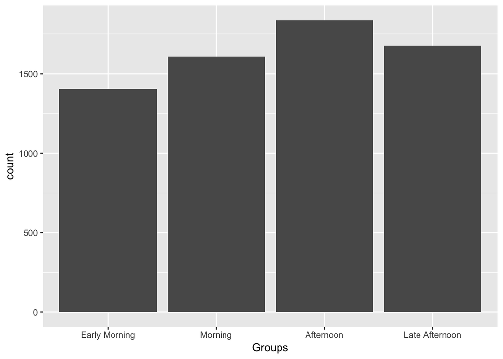

```r
D$Groups = factor(D$Groups, labels = c("Early Morning","Morning","Afternoon","Late Afternoon"))

ggplot(D, aes(x=Groups)) + geom_bar()
```

Other variables can be visualized as follows.

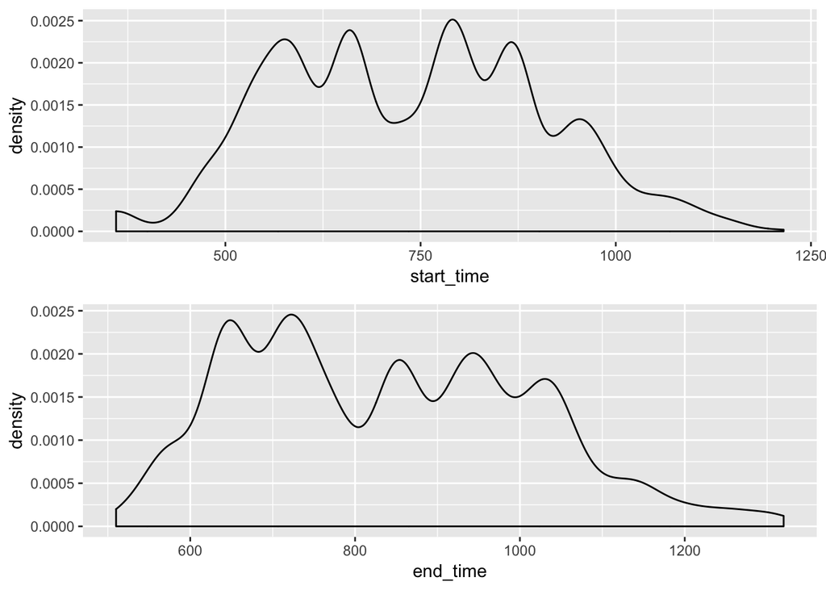

```r
f1 = ggplot(D, aes(x=start_time)) + geom_density()

f2 = ggplot(D, aes(x=end_time)) + geom_density()

grid.arrange(f1,f2)
```

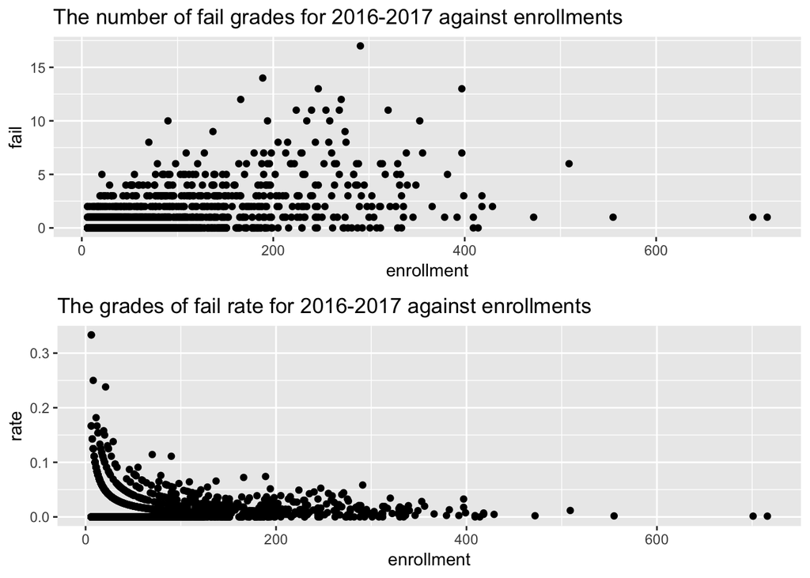

```r
f1 = ggplot(D, aes(x=enrollment,y=fail)) + geom_point() + labs(title = "The number of fail grades for 2016-2017 against enrollments")

f2 = ggplot(D, aes(x=enrollment,y=rate)) + geom_point() + labs(title = "The grades of fail rate for 2016-2017 against enrollments")

grid.arrange(f1,f2)
```

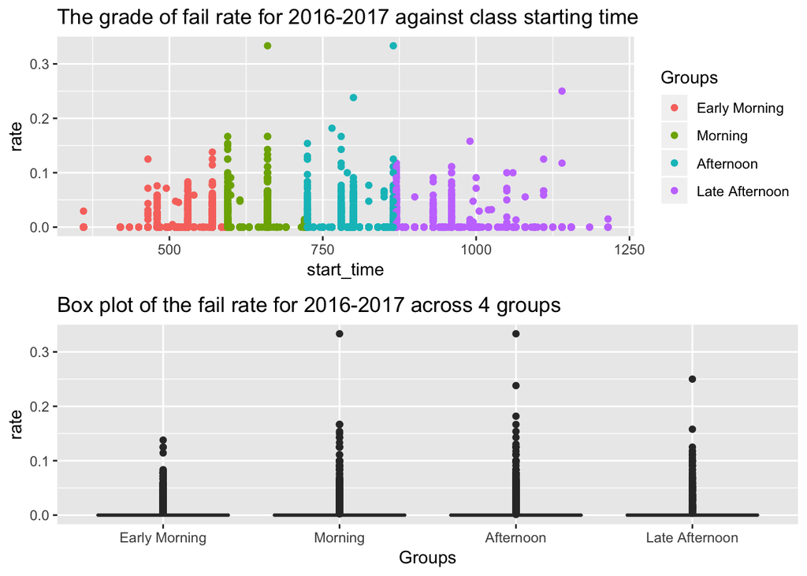

```r
f1 = ggplot(D, aes(x=start_time,y=rate,color=Groups)) + geom_point() + labs(title = "The grade of fail rate for 2016-2017 against class starting time")

f2 = ggplot(D, aes(x=Groups,y=rate)) + geom_boxplot() + labs(title = "Box plot of the fail rate for 2016-2017 across 4 groups")

grid.arrange(f1,f2)
```

Moreover, we summarize the grade of failure rate, split by class starting time.

```r
data.frame(Groups=levels(D$Groups), Size=count(D,Groups)$n, Mean=aggregate(D["rate"], D["Groups"], mean)$rate, SD=aggregate(D["rate"], D["Groups"], sd)$rate)
```

```
##           Groups Size        Mean         SD
## 1  Early Morning 1405 0.004221336 0.01421338
## 2        Morning 1606 0.006566851 0.02118391
## 3      Afternoon 1838 0.005856454 0.02004117
## 4 Late Afternoon 1678 0.004386507 0.01701933
```

### Kruskal–Wallis test

We will compare means across 4 groups, i.e., Early Morning (EM), Morning (M), Afternoon (A) and Late Afternoon (LA) using a single hypothesis test. Let $\mu_{i}$ denote the mean of grade of failure rate for $i \in \{EM,M,A,LA\}$. Consider the hypotheses:

- $H_{0}$: $\mu_{EM}=\mu_{M}=\mu_{A}=\mu_{LA}$.
- $H_{A}$: The average grade of failure rate $\mu_{i}$ for some $i$ varies across some groups.

First, we will try to apply an ANOVA test and there are three conditions we must check:

1. **Independence** Our data were not sampled. However, there are not obvious reasons why independence would not hold for all observations.
2. **Constant variance** This assumption can be examined by the box plot of grade of failure rate for 2016-2017 across 4 groups. There are some prominent outliers visible in the Morning, Afternoon and Late Afternoon groups. Notice that there are 1400 and more observations in each group.
3. **Approximately normal** This assumption fails because there are deviations from normality. The normal probability plots for each group of the data are shown below.

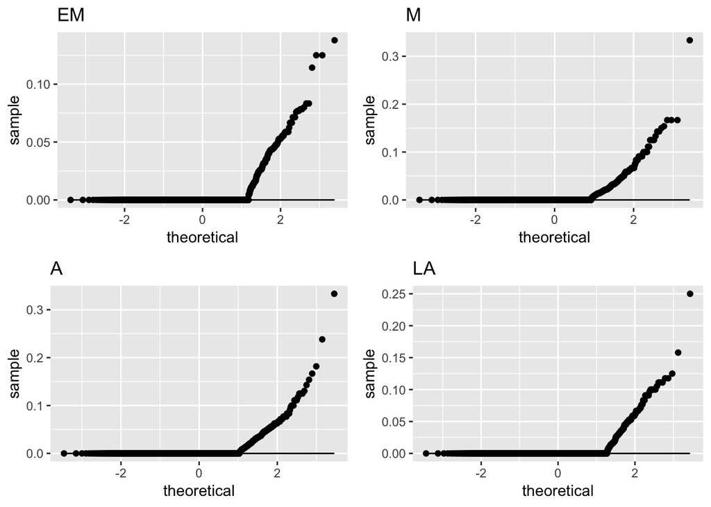

```r
f1 = ggplot(D[D$Groups=="Early Morning",], aes(sample=rate)) + stat_qq() + stat_qq_line() + labs(title="EM")

f2 = ggplot(D[D$Groups=="Morning",], aes(sample=rate)) + stat_qq() + stat_qq_line() + labs(title="M")

f3 = ggplot(D[D$Groups=="Afternoon",], aes(sample=rate)) + stat_qq() + stat_qq_line() + labs(title="A")

f4 = ggplot(D[D$Groups=="Late Afternoon",], aes(sample=rate)) + stat_qq() + stat_qq_line() + labs(title="LA")

grid.arrange(f1,f2,f3,f4,nrow=2)
```

The below figure gives another view of ANOVA’s assumptions.

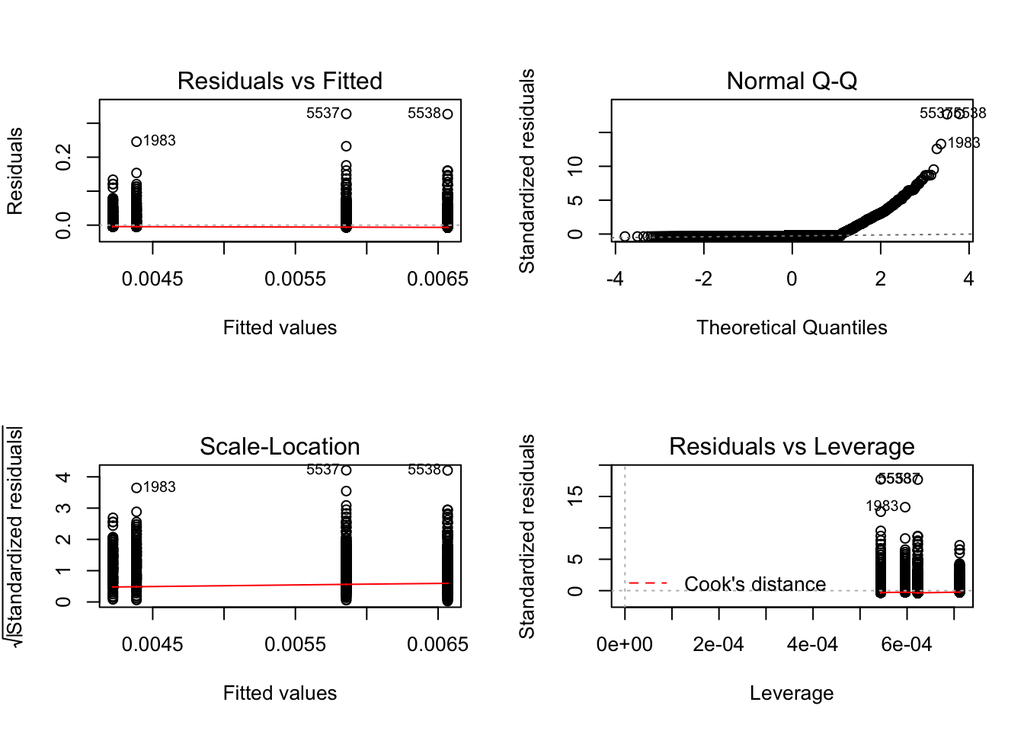

```r
par(mfrow=c(2,2))
plot(aov(rate~Groups, data=D))
```

Since the assumptions of ANOVA test are not met, we will use the Kruskal–Wallis test instead. It can be summarized in the below table.

```r
kruskal.test(rate~Groups, data=D)
```

```
##
##  Kruskal-Wallis rank sum test
##
## data:  rate by Groups
## Kruskal-Wallis chi-squared = 42.858, df = 3, p-value = 2.638e-09
```

The p-value of the test is $2.638\times 10^{-9}$, less than the significance level of 0.05. Therefore, we reject the null hypothesis and conclude that the difference in the average grade of failure rate varies across some groups. Next we use Wilcoxon rank test with the Bonferroni correction to find which of the groups are actually different.

```r
pairwise.wilcox.test(D$rate, D$Groups, p.adjust.method = "bonferroni")
```

```
##
##  Pairwise comparisons using Wilcoxon rank sum test
##
## data:  D$rate and D$Groups
##
##                Early Morning Morning Afternoon
## Morning        0.00011       -       -
## Afternoon      0.05331       0.34476 -
## Late Afternoon 0.90460       1.2e-08 0.00012
##
## P value adjustment method: bonferroni
```

Note that the Bonferroni correction suggests that a more stringent significance level is

```r
k = 4 # 4 groups

0.05/(k*(k-1)/2)
```

```
## [1] 0.008333333
```